# Homework 1 Solution

Haoke Lian (605266888)

2020/1/19

## Q2

**Here is a screenshot of my completion report:**

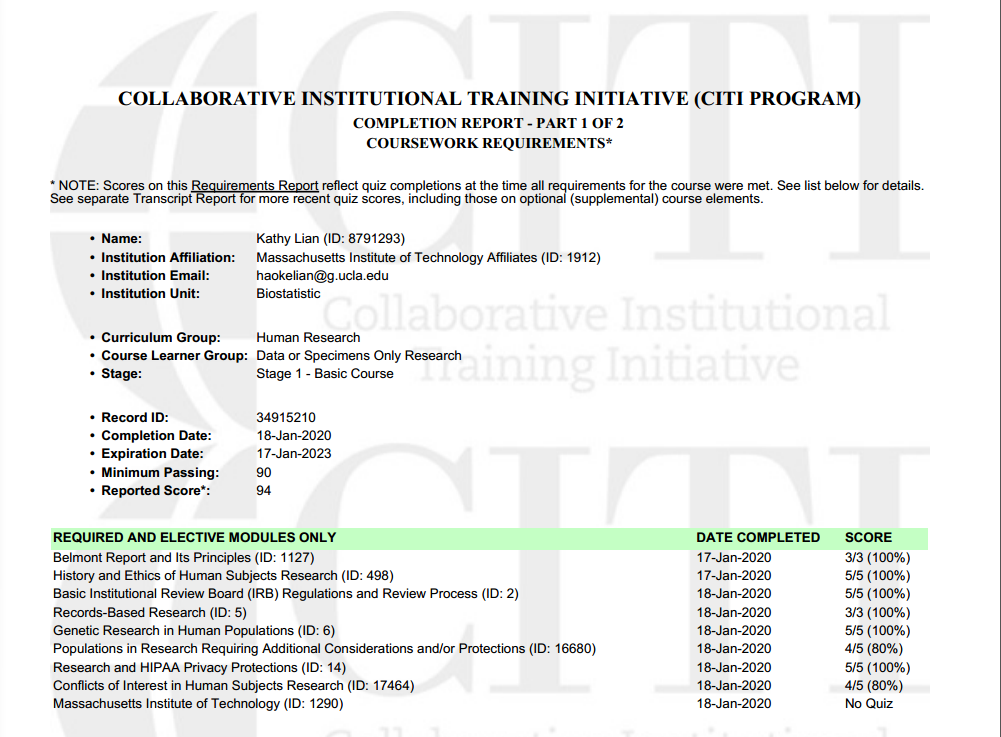

3. The output is listed below the script

```bash
for datafile in /home/203bdata/mimic-iii/*.csv
  do
    ls $datafile
  done
```

```
## /home/203bdata/mimic-iii/ADMISSIONS.csv
## /home/203bdata/mimic-iii/CALLOUT.csv
## /home/203bdata/mimic-iii/CAREGIVERS.csv
## /home/203bdata/mimic-iii/CHARTEVENTS.csv
## /home/203bdata/mimic-iii/CPTEVENTS.csv
## /home/203bdata/mimic-iii/DATETIMEEVENTS.csv
## /home/203bdata/mimic-iii/D_CPT.csv
## /home/203bdata/mimic-iii/DIAGNOSES_ICD.csv
## /home/203bdata/mimic-iii/D_ICD_DIAGNOSES.csv
## /home/203bdata/mimic-iii/D_ICD_PROCEDURES.csv
## /home/203bdata/mimic-iii/D_ITEMS.csv
## /home/203bdata/mimic-iii/D_LABITEMS.csv
## /home/203bdata/mimic-iii/DRGCODES.csv
## /home/203bdata/mimic-iii/ICUSTAYS.csv
## /home/203bdata/mimic-iii/INPUTEVENTS_CV.csv
## /home/203bdata/mimic-iii/INPUTEVENTS_MV.csv
## /home/203bdata/mimic-iii/LABEVENTS.csv
## /home/203bdata/mimic-iii/MICROBIOLOGYEVENTS.csv
## /home/203bdata/mimic-iii/NOTEEVENTS.csv
## /home/203bdata/mimic-iii/OUTPUTEVENTS.csv
## /home/203bdata/mimic-iii/PATIENTS.csv
## /home/203bdata/mimic-iii/PRESCRIPTIONS.csv
## /home/203bdata/mimic-iii/PROCEDUREEVENTS_MV.csv
## /home/203bdata/mimic-iii/PROCEDURES_ICD.csv
## /home/203bdata/mimic-iii/SERVICES.csv
## /home/203bdata/mimic-iii/TRANSFERS.csv
```

Numbers of lines and file names are listed in the same order:

```bash
 for datafile in /home/203bdata/mimic-iii/*.csv
  do
    wc -l $datafile
  done
```

```
## 58977 /home/203bdata/mimic-iii/ADMISSIONS.csv
## 34500 /home/203bdata/mimic-iii/CALLOUT.csv
## 7568 /home/203bdata/mimic-iii/CAREGIVERS.csv
## 1048575 /home/203bdata/mimic-iii/CHARTEVENTS.csv
## 573147 /home/203bdata/mimic-iii/CPTEVENTS.csv
## 4485938 /home/203bdata/mimic-iii/DATETIMEEVENTS.csv
## 135 /home/203bdata/mimic-iii/D_CPT.csv
## 651048 /home/203bdata/mimic-iii/DIAGNOSES_ICD.csv
## 14568 /home/203bdata/mimic-iii/D_ICD_DIAGNOSES.csv
## 3883 /home/203bdata/mimic-iii/D_ICD_PROCEDURES.csv
## 12488 /home/203bdata/mimic-iii/D_ITEMS.csv
## 754 /home/203bdata/mimic-iii/D_LABITEMS.csv
## 125558 /home/203bdata/mimic-iii/DRGCODES.csv
## 61533 /home/203bdata/mimic-iii/ICUSTAYS.csv
## 17527936 /home/203bdata/mimic-iii/INPUTEVENTS_CV.csv
## 3618992 /home/203bdata/mimic-iii/INPUTEVENTS_MV.csv
## 27854056 /home/203bdata/mimic-iii/LABEVENTS.csv
## 631727 /home/203bdata/mimic-iii/MICROBIOLOGYEVENTS.csv
## 91691299 /home/203bdata/mimic-iii/NOTEEVENTS.csv
## 4349219 /home/203bdata/mimic-iii/OUTPUTEVENTS.csv
## 46521 /home/203bdata/mimic-iii/PATIENTS.csv
## 4156451 /home/203bdata/mimic-iii/PRESCRIPTIONS.csv
## 258067 /home/203bdata/mimic-iii/PROCEDUREEVENTS_MV.csv
## 240096 /home/203bdata/mimic-iii/PROCEDURES_ICD.csv
## 73344 /home/203bdata/mimic-iii/SERVICES.csv
## 261898 /home/203bdata/mimic-iii/TRANSFERS.csv
```

4. The first 10 lines of ADMISSIONS.csv are:

```bash
  head /home/203bdata/mimic-iii/ADMISSIONS.csv
```

```
## "ROW_ID","SUBJECT_ID","HADM_ID","ADMITTIME","DISCHTIME","DEATHTIME","ADMISSION_TYPE","ADMISSION_LOCATION","DISCHARGE_LOCATION","INSURANCE","LANGUAGE","RELIGION","MARITAL_STATUS","ETHNICITY","EDREGTIME","EDOUTTIME","DIAGNOSIS","HOSPITAL_EXPIRE_FLAG","HAS_CHARTEVENTS_DATA"
## 21,22,165315,2196-04-09 12:26:00,2196-04-10 15:54:00,,"EMERGENCY","EMERGENCY ROOM ADMIT","DISC-TRAN CANCER/CHLDRN H","Private",,"UNOBTAINABLE","MARRIED","WHITE",2196-04-09 10:06:00,2196-04-09 13:24:00,"BENZODIAZEPINE OVERDOSE",0,1
## 22,23,152223,2153-09-03 07:15:00,2153-09-08 19:10:00,,"ELECTIVE","PHYS REFERRAL/NORMAL DELI","HOME HEALTH CARE","Medicare",,"CATHOLIC","MARRIED","WHITE",,,"CORONARY ARTERY DISEASE\CORONARY ARTERY BYPASS GRAFT/SDA",0,1
## 23,23,124321,2157-10-18 19:34:00,2157-10-25 14:00:00,,"EMERGENCY","TRANSFER FROM HOSP/EXTRAM","HOME HEALTH CARE","Medicare","ENGL","CATHOLIC","MARRIED","WHITE",,,"BRAIN MASS",0,1
## 24,24,161859,2139-06-06 16:14:00,2139-06-09 12:48:00,,"EMERGENCY","TRANSFER FROM HOSP/EXTRAM","HOME","Private",,"PROTESTANT QUAKER","SINGLE","WHITE",,,"INTERIOR MYOCARDIAL INFARCTION",0,1
## 25,25,129635,2160-11-02 02:06:00,2160-11-05 14:55:00,,"EMERGENCY","EMERGENCY ROOM ADMIT","HOME","Private",,"UNOBTAINABLE","MARRIED","WHITE",2160-11-02 01:01:00,2160-11-02 04:27:00,"ACUTE CORONARY SYNDROME",0,1
## 26,26,197661,2126-05-06 15:16:00,2126-05-13 15:00:00,,"EMERGENCY","TRANSFER FROM HOSP/EXTRAM","HOME","Medicare",,"CATHOLIC","SINGLE","UNKNOWN/NOT SPECIFIED",,,"V-TACH",0,1
## 27,27,134931,2191-11-30 22:16:00,2191-12-03 14:45:00,,"NEWBORN","PHYS REFERRAL/NORMAL DELI","HOME","Private",,"CATHOLIC",,"WHITE",,,"NEWBORN",0,1
## 28,28,162569,2177-09-01 07:15:00,2177-09-06 16:00:00,,"ELECTIVE","PHYS REFERRAL/NORMAL DELI","HOME HEALTH CARE","Medicare",,"CATHOLIC","MARRIED","WHITE",,,"CORONARY ARTERY DISEASE\CORONARY ARTERY BYPASS GRAFT/SDA",0,1
## 29,30,104557,2172-10-14 14:17:00,2172-10-19 14:37:00,,"URGENT","TRANSFER FROM HOSP/EXTRAM","HOME HEALTH CARE","Medicare",,"CATHOLIC","MARRIED","UNKNOWN/NOT SPECIFIED",,,"UNSTABLE ANGINA\CATH",0,1
```

The last 10 lines of ADMISSIONS.csv are:

```bash
  tail /home/203bdata/mimic-iii/ADMISSIONS.csv
```

```
## 58589,98768,127022,2112-09-15 09:45:00,2112-09-17 08:20:00,2112-09-17 08:20:00,"EMERGENCY","CLINIC REFERRAL/PREMATURE","DEAD/EXPIRED","Medicare","ENGL","JEWISH","WIDOWED","WHITE",2112-09-15 09:30:00,2112-09-15 11:46:00,"LEUKOCYTOSIS",1,1
## 58590,98769,141860,2125-02-22 22:18:00,2125-03-05 17:22:00,,"EMERGENCY","CLINIC REFERRAL/PREMATURE","SNF","Medicare","ENGL","CATHOLIC","WIDOWED","WHITE",2125-02-22 19:52:00,2125-02-22 22:37:00,"ISCHEMIC COLITIS",0,1
## 58591,98790,187987,2200-10-15 01:58:00,2200-10-25 15:43:00,,"EMERGENCY","EMERGENCY ROOM ADMIT","HOME HEALTH CARE","Private","ENGL","NOT SPECIFIED","MARRIED","WHITE",2200-10-14 23:42:00,2200-10-15 04:41:00,"JOINT EFFUSION",0,1
## 58592,98794,190603,2127-11-07 11:00:00,2127-11-11 14:30:00,,"ELECTIVE","PHYS REFERRAL/NORMAL DELI","HOME HEALTH CARE","Medicare","ENGL","CATHOLIC","MARRIED","WHITE",,,"AORTIC STENOSIS\AORTIC VALVE REPLACEMENT /SDA",0,1
## 58593,98797,105447,2132-12-24 20:06:00,2132-12-25 12:00:00,2132-12-25 12:00:00,"EMERGENCY","EMERGENCY ROOM ADMIT","DEAD/EXPIRED","Medicare","ENGL","CATHOLIC","WIDOWED","WHITE",2132-12-24 18:53:00,2132-12-24 21:41:00,"ALTERED MENTAL STATUS",1,1
## 58594,98800,191113,2131-03-30 21:13:00,2131-04-02 15:02:00,,"EMERGENCY","CLINIC REFERRAL/PREMATURE","HOME","Private","ENGL","NOT SPECIFIED","SINGLE","WHITE",2131-03-30 19:44:00,2131-03-30 22:41:00,"TRAUMA",0,1
## 58595,98802,101071,2151-03-05 20:00:00,2151-03-06 09:10:00,2151-03-06 09:10:00,"EMERGENCY","CLINIC REFERRAL/PREMATURE","DEAD/EXPIRED","Medicare","ENGL","CATHOLIC","WIDOWED","WHITE",2151-03-05 17:23:00,2151-03-05 21:06:00,"SAH",1,1
## 58596,98805,122631,2200-09-12 07:15:00,2200-09-20 12:08:00,,"ELECTIVE","PHYS REFERRAL/NORMAL DELI","HOME HEALTH CARE","Private","ENGL","NOT SPECIFIED","MARRIED","WHITE",,,"RENAL CANCER/SDA",0,1
## 58597,98813,170407,2128-11-11 02:29:00,2128-12-22 13:11:00,,"EMERGENCY","EMERGENCY ROOM ADMIT","SNF","Private","ENGL","CATHOLIC","MARRIED","WHITE",2128-11-10 23:48:00,2128-11-11 03:16:00,"S/P FALL",0,0
## 58598,98813,190264,2131-10-25 03:09:00,2131-10-26 17:44:00,,"EMERGENCY","CLINIC REFERRAL/PREMATURE","HOME","Private","ENGL","CATHOLIC","MARRIED","WHITE",2131-10-25 00:08:00,2131-10-25 04:35:00,"INTRACRANIAL HEMORRHAGE",0,1
```

Calculate the number of rows:

```bash
   awk 'END { print NR }' /home/203bdata/mimic-iii/ADMISSIONS.csv
```

```
## 58977
```

The number of patients by calcualting number of different subject ID

```bash
    awk -F, '{ print $2 }' /home/203bdata/mimic-iii/ADMISSIONS.csv | tail -n +2 | sort | uniq | awk 'END {print NR}'
```

```
## 46520
```

The possible values of each variable are listed below: INSURANCE:

```bash
     awk -F, '{ print $10 }' /home/203bdata/mimic-iii/ADMISSIONS.csv | tail -n +2 | sort | uniq
```

```
## "Government"
## "Medicaid"
## "Medicare"
## "Private"
## "Self Pay"
```

LANGUAGE:

```bash
     awk -F, '{ print $11 }' /home/203bdata/mimic-iii/ADMISSIONS.csv | tail -n +2 | sort | uniq
```

```
##
## "ALBA"
## "AMER"
## "*AMH"
## "*ARA"
## "ARAB"
## "*ARM"
## "* BE"
## "*BEN"
## "BENG"
## "*BOS"
## "*BUL"
## "*BUR"
## "CAMB"
## "*CAN"
## "CANT"
## "CAPE"
## "*CDI"
## "*CHI"
## "*CRE"
## "*DEA"
## "*DUT"
## "ENGL"
## "ETHI"
## "*FAR"
## "*FIL"
## "FREN"
## "* FU"
## "*FUL"
## "GERM"
## "GREE"
## "*GUJ"
## "HAIT"
## "HIND"
## "*HUN"
## "*IBO"
## "ITAL"
## "JAPA"
## "*KHM"
## "KORE"
```

[output cut: 21 more lines]

```
## "SPAN"
## "** T"
## "TAGA"
## "*TAM"
## "*TEL"
## "THAI"
## "**TO"
## "*TOI"
## "*TOY"
## "TURK"
## "*URD"
## "URDU"
## "VIET"
## "*YID"
## "*YOR"
```

RELIGION:

```bash
     awk -F, '{ print $12 }' /home/203bdata/mimic-iii/ADMISSIONS.csv | tail -n +2 | sort | uniq
```

```
##
## "7TH DAY ADVENTIST"
## "BAPTIST"
## "BUDDHIST"
## "CATHOLIC"
## "CHRISTIAN SCIENTIST"
## "EPISCOPALIAN"
## "GREEK ORTHODOX"
## "HEBREW"
## "HINDU"
## "JEHOVAH'S WITNESS"
## "JEWISH"
## "LUTHERAN"
## "METHODIST"
## "MUSLIM"
## "NOT SPECIFIED"
## "OTHER"
## "PROTESTANT QUAKER"
## "ROMANIAN EAST. ORTH"
## "UNITARIAN-UNIVERSALIST"
## "UNOBTAINABLE"
```

MARITAL_STATUS:

```bash
     awk -F, '{ print $13 }' /home/203bdata/mimic-iii/ADMISSIONS.csv | tail -n +2 | sort | uniq
```

```
##
## "DIVORCED"
## "LIFE PARTNER"
## "MARRIED"
## "SEPARATED"
## "SINGLE"
## "UNKNOWN (DEFAULT)"
## "WIDOWED"
```

ETHNICITY:

```bash
     awk -F, '{ print $14 }' /home/203bdata/mimic-iii/ADMISSIONS.csv | tail -n +2 | sort | uniq
```

```
## "AMERICAN INDIAN/ALASKA NATIVE"
## "AMERICAN INDIAN/ALASKA NATIVE FEDERALLY RECOGNIZED TRIBE"
## "ASIAN"
## "ASIAN - ASIAN INDIAN"
## "ASIAN - CAMBODIAN"
## "ASIAN - CHINESE"
## "ASIAN - FILIPINO"
## "ASIAN - JAPANESE"
## "ASIAN - KOREAN"
## "ASIAN - OTHER"
## "ASIAN - THAI"
## "ASIAN - VIETNAMESE"
## "BLACK/AFRICAN"
## "BLACK/AFRICAN AMERICAN"
## "BLACK/CAPE VERDEAN"
## "BLACK/HAITIAN"
## "CARIBBEAN ISLAND"
## "HISPANIC/LATINO - CENTRAL AMERICAN (OTHER)"
## "HISPANIC/LATINO - COLOMBIAN"
## "HISPANIC/LATINO - CUBAN"
## "HISPANIC/LATINO - DOMINICAN"
## "HISPANIC/LATINO - GUATEMALAN"
## "HISPANIC/LATINO - HONDURAN"
## "HISPANIC/LATINO - MEXICAN"
## "HISPANIC/LATINO - PUERTO RICAN"
## "HISPANIC/LATINO - SALVADORAN"
## "HISPANIC OR LATINO"
## "MIDDLE EASTERN"
## "MULTI RACE ETHNICITY"
## "NATIVE HAWAIIAN OR OTHER PACIFIC ISLANDER"
## "OTHER"
## "PATIENT DECLINED TO ANSWER"
## "PORTUGUESE"
## "SOUTH AMERICAN"
## "UNABLE TO OBTAIN"
## "UNKNOWN/NOT SPECIFIED"
## "WHITE"
## "WHITE - BRAZILIAN"
## "WHITE - EASTERN EUROPEAN"
## "WHITE - OTHER EUROPEAN"
## "WHITE - RUSSIAN"
```

The number of Hispanic patients are calculated the number of `HISPANIC` in the colume of `ETHNICITY`

```bash
    awk -F, '{ print $14 }' /home/203bdata/mimic-iii/ADMISSIONS.csv | tail -n +2 | sort | grep -o HISPANIC | wc -l
```

```
## 2128
```

## Q3

1. First, get the txt:

```bash
    curl http://www.gutenberg.org/cache/epub/42671/pg42671.txt > pride_and_prejudice.txt
```

```
##   % Total    % Received % Xferd  Average Speed   Time    Time     Time  Current
##                                  Dload  Upload   Total   Spent    Left  Speed
##
  0     0    0     0    0     0      0      0 --:--:-- --:--:-- --:--:--     0
 32  708k   32  230k    0     0   308k      0  0:00:02 --:--:--  0:00:02  307k
100  708k  100  708k    0     0   631k      0  0:00:01  0:00:01 --:--:--  632k
```

The tabulate of times of main characters mentioned is listed as below:

```bash
    printf 'Name       ''Times Metioned\n'
    for name in 'Elizabeth' 'Darcy' 'Jane' 'Lydia'
      do count=$(grep -o $name pride_and_prejudice.txt | wc -l)
      printf '%-15s%-10s\n' $name $count
      done
```

```
## Name       Times Metioned
## Elizabeth      634
## Darcy          417
## Jane           294
## Lydia          170
```

2. The output of two commands are text files with the same content:

```bash
    echo 'hello, world' > test1.txt
```

The first command means that everything that’s in “test1.txt” will be deleted, and “hello world” will be written to it (which means that “hello world” will be right at the beginning of “test1.txt”.

```bash
    echo 'hello, world' >> test2.txt
```

The second command means that “hello, world” will be appended to “test2.txt”, so nothing will be deleted from “test2.txt”, and “hello, world will be at the end of”test2.txt".

3. Start the editor `vi` and save the file as `middle.sh`. Then use `chmod 755 middle.sh`.

Excute the file to output middle lines.

```bash
    cd ~
    ./middle.sh pride_and_prejudice.txt 20 5
```

```
##
## Author: Jane Austen
##
## Editor: R. W. (Robert William) Chapman
##
```

Command line arguments are accessed using numeric indexes inside a shell script preceded with a dollar($) sign. That is, first argument can be referred as $1, second as $2 and third as $3.

The first line `#!/bin/sh` selects the `sh` shell. Problems arise when not using `#!/bin/sh` because the script-maker assumes the link is to bash as the default, but they function differently.

Then delete the file.

```bash
    rm pride_and_prejudice.txt
```

## Q4

1. This is my `runSim.R`code:

```bash
    cat runSim.R
```

```
## ## The code is used for automatic simulation based on given seed and number of replicates
## ## Arguments: nVals (sample size), disTypes (distribution)
## ##            seed (random seed by input) and rep (number of replicates by input)
## ## Output: report the average mean squared error (MSE)
## ##         of primed-indexed average estimator  and the classical sample average estimator
##
## ## parsing command arguments
## for (arg in commandArgs(TRUE)){
##   eval(parse(text=arg))
## }
##
## ## check if a given integer is prime
## isPrime = function(n){
##   if (n<=3){
##     return (TRUE)
##   }
##   if (any((n %% 2: floor(sqrt(n)))==0)){
##     return (FALSE)
##   }
##   return (TRUE)
## }
##
## ## estimate mean only using observation with prime indicies
## estMeanPrimes = function(x){
##   n = length(x)
##   ind = sapply(1:n,isPrime)
##   return (mean(x[ind]))
## }
##
## ## generate seed
## set.seed (seed)
##
## ## calculate MSE
## mseSampAvg = 0
## msePrimeAvg = 0
##
## for (r in 1:rep){
##   # simulate data
##   if (dist == "gaussian"){
##     x = rnorm(n)
##   } else if (dist == "t1"){
##     x = rt(n,df=1)
##   } else if (dist =="t5"){
##     x = rt(n,df=5)
##   } else{
##     stop("unrecohnized distribution")
##   }
##   # two methods
##   mseSampAvg = mseSampAvg + mean(x)^2
##   msePrimeAvg = msePrimeAvg + estMeanPrimes(x)^2
## }
##
## cat(msePrimeAvg/rep,"\t",mseSampAvg/rep,"\n")
```

Quote the runSim.R in bash shell. Output MSEs of primed-indexed average estimator and the classical sample average.

```bash
    Rscript runSim.R n=100 dist=\"gaussian\" seed=203 rep=50
```

```
## 0.03926458    0.01146443
```

2. This is my `autoSim.R`code:

```bash
    cat autoSim.R
```

```
## ## The code is used for automatic simulation based on given seed and number of replicates
## ## Arguments: nVals (sample size), disTypes (distribution)
## ##            seed (random seed by input) and rep (number of replicates by input)
## ## Output: report the average mean squared error (MSE)
## ##         of primed-indexed average estimator  and the classical sample average estimator
##
## ## generate sample sizes and distribution types automatically
## nVals <- seq(100, 500, by=100)
## distTypes = c("gaussian", "t1", "t5")
## seed <- 203
## rep <- 50
##
## ## simulate with runSim.R
## for (dist in distTypes){
##   for (n in nVals) {
##     arg <- paste("n=", n, " dist=", shQuote(shQuote(dist))," seed=", seed, " rep=", rep, sep="")
##     oFile <- paste("n_", n,"_dist_", dist, ".txt", sep="")
##     sysCall <- paste("nohup Rscript runSim.R ", arg, " > ", oFile, sep="")
##     system(sysCall, wait = FALSE)
##    print(paste("sysCall=", sysCall, sep=""))
##   }
## }
```

3. Call autoSim.R and generate simulation data.

```bash
    Rscript autoSim.R
```

```
## [1] "sysCall=nohup Rscript runSim.R n=100 dist=\"'gaussian'\" seed=203 rep=50 > n_100_dist_gaussian.txt"
## [1] "sysCall=nohup Rscript runSim.R n=200 dist=\"'gaussian'\" seed=203 rep=50 > n_200_dist_gaussian.txt"
## [1] "sysCall=nohup Rscript runSim.R n=300 dist=\"'gaussian'\" seed=203 rep=50 > n_300_dist_gaussian.txt"
## [1] "sysCall=nohup Rscript runSim.R n=400 dist=\"'gaussian'\" seed=203 rep=50 > n_400_dist_gaussian.txt"
## [1] "sysCall=nohup Rscript runSim.R n=500 dist=\"'gaussian'\" seed=203 rep=50 > n_500_dist_gaussian.txt"
## [1] "sysCall=nohup Rscript runSim.R n=100 dist=\"'t1'\" seed=203 rep=50 > n_100_dist_t1.txt"
## [1] "sysCall=nohup Rscript runSim.R n=200 dist=\"'t1'\" seed=203 rep=50 > n_200_dist_t1.txt"
## [1] "sysCall=nohup Rscript runSim.R n=300 dist=\"'t1'\" seed=203 rep=50 > n_300_dist_t1.txt"
## [1] "sysCall=nohup Rscript runSim.R n=400 dist=\"'t1'\" seed=203 rep=50 > n_400_dist_t1.txt"
## [1] "sysCall=nohup Rscript runSim.R n=500 dist=\"'t1'\" seed=203 rep=50 > n_500_dist_t1.txt"
## [1] "sysCall=nohup Rscript runSim.R n=100 dist=\"'t5'\" seed=203 rep=50 > n_100_dist_t5.txt"
## [1] "sysCall=nohup Rscript runSim.R n=200 dist=\"'t5'\" seed=203 rep=50 > n_200_dist_t5.txt"
## [1] "sysCall=nohup Rscript runSim.R n=300 dist=\"'t5'\" seed=203 rep=50 > n_300_dist_t5.txt"
## [1] "sysCall=nohup Rscript runSim.R n=400 dist=\"'t5'\" seed=203 rep=50 > n_400_dist_t5.txt"
## [1] "sysCall=nohup Rscript runSim.R n=500 dist=\"'t5'\" seed=203 rep=50 > n_500_dist_t5.txt"
```

Table.R is shown as below.

```bash
    cat Table.R
```

```
## ## This code is used to report outputs of autoSim.R in a form of table
##
## ## count output files of autoSim in folder
## wd = getwd()
## fileName <- dir(wd,pattern='n*.txt')
## fileNum <- length(fileName)
## rowNum <- fileNum/3
##
## ## initiate arguments and vectors
## distTypes = c("gaussian", "t1", "t5")
## N <- c()
## N_ <- c()
## data_1 <- c()
## data_2 <- c()
## data_3 <- c()
## datalist_1 <- c()
## datalist_2 <- c()
## datalist_3 <- c()
## MSE <- c()
##
## ## store MSE data of different distTypes and sample sizes separately
## for (n in 1:10000){
##   for (d in distTypes){
##     Fname <- paste("n_",n,"_dist_",d,".txt",sep="")
##     if (file.exists(Fname)==TRUE){
##       MSE <- tryCatch(read.table(Fname,header=FALSE))
##       if (d=="gaussian"){
##         data_1 <- t(MSE)
##         datalist_1 <- c(datalist_1,data_1)
##       }else if (d=="t1"){
##         data_2 <- t(MSE)
##         datalist_2 <- c(datalist_2,data_2)
##       }else if (d=="t5"){
##         data_3 <- t(MSE)
##         datalist_3 <- c(datalist_3,data_3)
##       }
##       # store sample sizes
##       N <- c(N,rep(n,2))
##     }
##   }
## }
##
## # delete repeating N numbers
## for (r in 1:(fileNum*2)){
##   if (floor(r/3)==r/3){
##     N_[r/3] = N[r]
##   }
## }
##
## # set 2nd column by replication
## M <- rep(c('PrimeAvg','SampAvg'),rowNum)
##
## # stitch the table and present
## table <- data.frame(n=N_,Method=M,Gaussian=datalist_1,t1=datalist_2,t5=datalist_3)
## print(table)
```

Then report the average MSEs with a table:

```bash
    Rscript Table.R
```

```
##      n   Method    Gaussian        t1          t5
## 1  100 PrimeAvg 0.039264580  43.72672 0.047281910
## 2  100  SampAvg 0.011464430  26.76927 0.011320570
## 3  200 PrimeAvg 0.024001610  20.91532 0.043965280
## 4  200  SampAvg 0.005764383  43.41982 0.006573672
## 5  300 PrimeAvg 0.020514360 116.39670 0.042466820
## 6  300  SampAvg 0.004199221 138.45650 0.004420692
## 7  400 PrimeAvg 0.013456000  48.29149 0.027956910
## 8  400  SampAvg 0.002870221  76.24066 0.003922553
## 9  500 PrimeAvg 0.009396678 152.80850 0.019900230
## 10 500  SampAvg 0.002191460  53.47290 0.003111203
```